# IODS-Final

Tuure Parviainen

December 13, 2017

# IODS-Final: Boston dataset PCA and PCR

1. Normal unchanged dataset
   - 1a Normal train
   - 1b Normal test

## Data exploration

```r
knitr::opts_chunk$set(echo = TRUE, warning=FALSE)
require("easypackages") # for loading and installing many packages at one time
packages_to_load <- c("broom", "dplyr", "tidyverse", "corrplot", "ggplot2", "GGally", "caret", "devtools", "ggthemes", "scales", "reshape2", "FactoMineR", "factoextra", "pls", "visreg", "mgcv", "WVPlots")
packages(packages_to_load, prompt = TRUE) # lock'n'load install/load
```

```r
# set the seed to make your partition reproductible
set.seed(777)

# 1) Normal unchanged dataset
boston <- read.table("data/boston.txt")

# 70% of the sample size
sample_size <- floor(0.70 * nrow(boston))

train_ind <- sample(seq_len(nrow(boston)), size = sample_size)
# splitting data by the vector
trainb <- boston[train_ind, ]
testb <- boston[-train_ind, ]
```

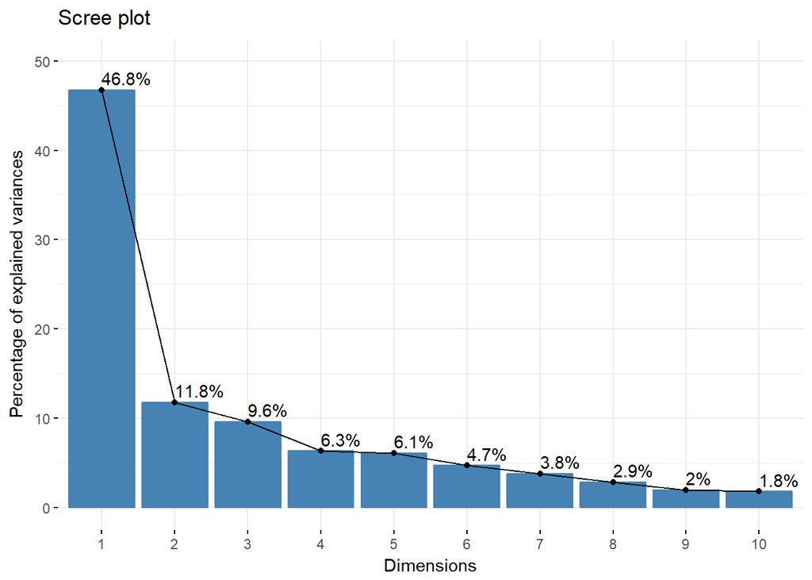

```r
######################################################################################
# PCA

# Note that, by default, the function PCA() [in FactoMineR], standardizes the data automatically during the PCA; so you don’t need do this transformation before the PCA.

res.pca <- PCA(boston, graph = FALSE)
#summary(res.pca)

# How many dimensions we need
fviz_eig(res.pca, addlabels = TRUE, ylim = c(0, 50))
```

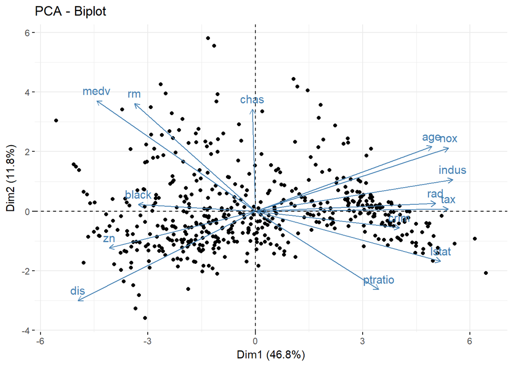

```r
# Individuals and dimensions
fviz_pca_biplot(res.pca, label = "var")
```

We can see from the figure that in the 1st dimension the first positive correlated variables are: proportion of non-retail business acres per town, index of accessibility to radial highways, proportion of owner-occupied units built prior to 1940.

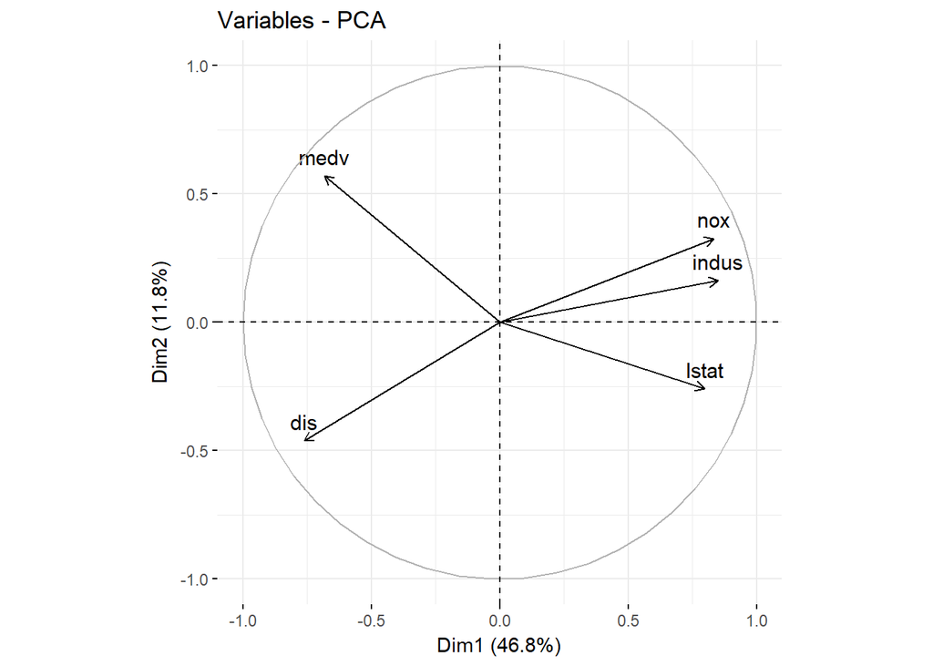

```r
# Contributions of variables to PC1, PC2, PC3
# fviz_contrib(res.pca, choice = "var", axes = 1, top = 10)
#fviz_contrib(res.pca, choice = "var", axes = 2, top = 10)
#fviz_contrib(res.pca, choice = "var", axes = 3, top = 10)
#fviz_contrib(res.pca, choice = "var", axes = 1:3, top = 10)

#eig.val <- get_eigenvalue(res.pca)
#eig.val

# With eigenvalue higher than 1 are included. dim 1:3.

# Most influential variables.
fviz_pca_var(res.pca, select.var= list(cos2 = 5))
```

```r
# With LM we had: crim + indus + age + dis + rad + ptratio + medv
# With PCA:  medv + indus + dis + lstat and nox
# The trouble is our data is still highly dimensional. What to do?
```

Here we can see the 5 most influential variables. These are medv: median value of owner-occupied homes divided by $1000s, nox: nitrogen oxides concentration (parts per 10 million). indus: proportion of non-retail business acres per town. lstat: lower status of the population (percent). and dis: weighted mean of distances to five Boston employment centres.

Next we are going to use the Principal component regression using pls-library.

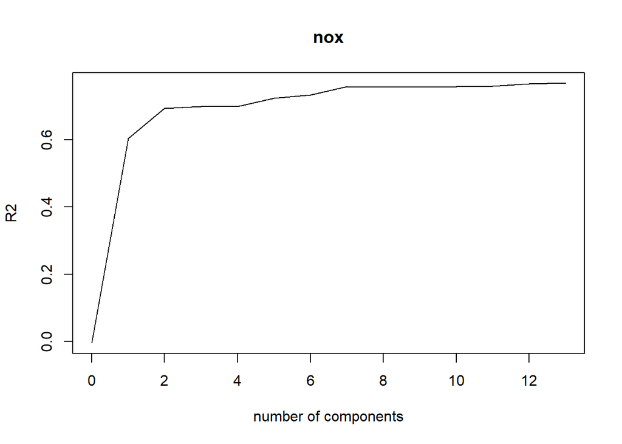

```r
######################################################################################
# LM on PCA so PCR - transformed dataset

pcr_model <- pcr(nox~., data = boston, scale = TRUE, validation = "CV")
#summary(pcr_model)

#validationplot(pcr_model)
#validationplot(pcr_model, val.type="MSEP")
validationplot(pcr_model, val.type = "R2")
```

```r
# What you would like to see is a low cross validation error with a lower number of components than the number of variables in your dataset. If this is not the case or if the smalles cross validation error occurs with a number of components close to the number of variables in the original data, then no dimensionality reduction occurs. In the example above, it looks like 3 components are enough to explain more than 90% of the variability in the data although the CV score is a little higher than with 4 or 5 components. Finally, note that 6 components explain all the variability as expected.
#predplot(pcr_model)
#coefplot(pcr_model)

#Test train
pcr_model <- pcr(nox~., data = trainb ,scale =TRUE, validation = "CV")

pcr_pred <- predict(pcr_model, testb, ncomp = 6)

# MSE
mean((pcr_pred - testb$nox)^2)
```

```
## [1] 0.003667294
```

```r
# 0.003793769
print("PCR seems slightly worse than linear regression.")
```

```
## [1] "PCR seems slightly worse than linear regression."
```

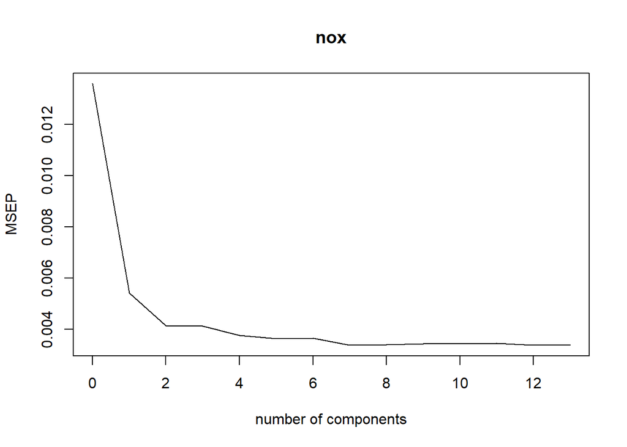

```r
#plot(pcr_model, ncomp = 6) # Plot of cross-validated predictions
#plot(pcr_model, "scores") # Score plot
#plot(pcr_model, "loadings", comps = 1:3) # The three first loadings
#plot(pcr_model, "coef", ncomp = 5) # Coefficients
#plot(pcr_model, "val") # RMSEP curves
plot(pcr_model, "val", val.type = "MSEP", estimate = "CV") # CV MSEP
```

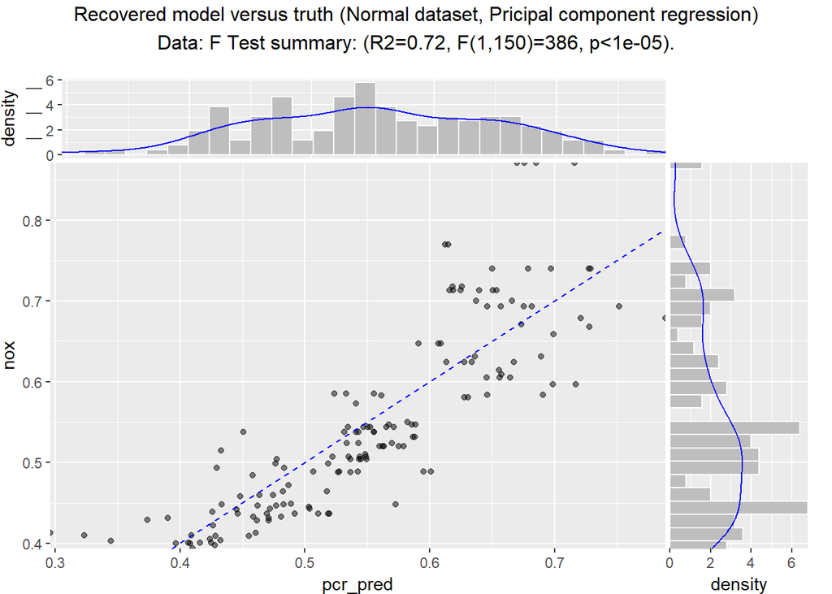

```r
pcr_pred <- data.frame(pcr_pred)
pcr.scatter<- cbind(pcr_pred, testb$nox)
colnames(pcr.scatter) <- c("pcr_pred","nox")

ScatterHist(pcr.scatter, "pcr_pred", "nox",
            smoothmethod="identity",
            annot_size=3,
            title="Recovered model versus truth (Normal dataset, Pricipal component regression)")
```

We were able to reduce the dimensions of the data to **6**, however we also reduced the R^2 to **72%** and with MSE (mean squared error) of **0.003667294**. The dimensionality reduction is similar than what can be achived by scaling and transforming the dataset. We can however achive even dimensionality reduction to **2** dimensions with R^2 of **68%**.